# Reproducible Research: Peer Assessment 1

## Loading and preprocessing the data

The first step in the project is to load data using the following R code:

```r
        setwd("repdata_data_activity")
        rawdata<-read.csv("activity.csv")

        ## Turn off scientific notation
        options(scipen=999)
```

## What is mean total number of steps taken per day?

The first analysis we will undertake looks at the data on a daily basis. This part of the assignment ignores missing values in the dataset.

### Total number of steps taken per day

```r
## 1. Calculate the total number of steps taken per day
        library("plyr",quietly=TRUE)
        library("dplyr",quietly=TRUE)
        steps<-rawdata %>%
                group_by(date) %>%
                summarize(total = sum(steps))
        meansteps<-mean(steps$total,na.rm=TRUE)
        meanstepsp<-prettyNum(meansteps,big.mark = ",")
```

The mean total steps taken each day is 10,766.19.

### Histogram of total steps each day

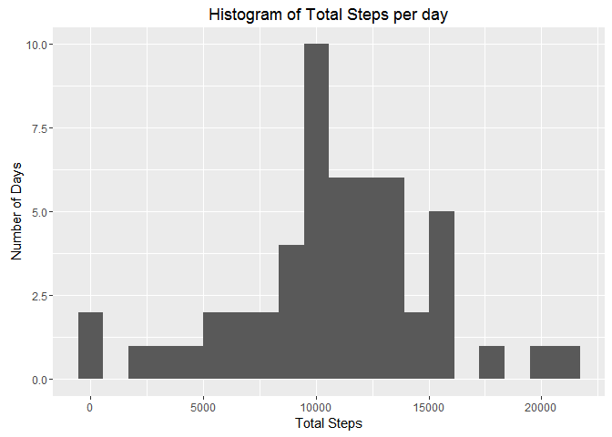

```r
## Make a histogram of the total number of steps taken each day
        library("ggplot2",quietly = TRUE)
        ## remove NA values so that we don't get warning messages
        steps3<-steps[!is.na(steps$total),]

        ## Create plot
        g<-ggplot(steps3,aes(steps3$total)) +
                geom_histogram(bins = 20)+
                ggtitle("Histogram of Total Steps per day") +
                xlab("Total Steps") +
                ylab("Number of Days")
        print(g)
```

### Mean and Median of total number of steps per day

Finally, we will calculate the median number of total steps per day.  
Note that the assignment asks for the mean, but we already did this above, so will just reuse that value.

```r
## Calculate and report the mean and median of the total number of steps taken per day

## we already computed the mean total number above, so just reusing that value
stepmedian1<-median(steps$total,na.rm = TRUE)
stepmedian1p<- prettyNum(stepmedian1,big.mark = ",")
```

The mean number of steps taken per day ignoring missing values is: 10,766.19.  
The median number of steps taken per day ignoring missing values is: 10,765.

## What is the average daily activity pattern?

In the second analysis, we will examine the data by 5 minute interval, rather than by day.

### 5-minute interval vs. avg number of steps, averaged across all days

This code will generate a plot of the 5-minute interveal vs. the average number of steps taken in the interval, averaged across all days.

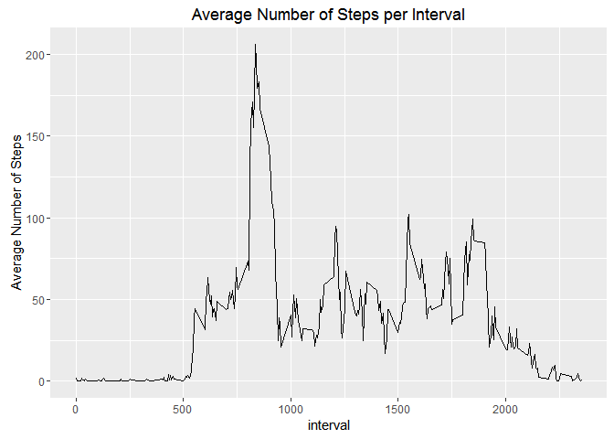

```r
## Make a time series plot (i.e. type = "l") of the 5-minute interval (x-axis) and the average number of steps taken, averaged across all days (y-axis)
        library ("stringr",quietly = TRUE)
        ## Create the data for the plot
        intervalsteps<- rawdata %>%
                group_by(interval) %>%
                summarize(average = mean(steps,na.rm = TRUE))

        ## Create the plot
        g<-ggplot(intervalsteps,aes(interval,average)) +
                geom_line() +
                ggtitle("Average Number of Steps per Interval") +
                ylab("Average Number of Steps")
        print(g)
```

### Which 5-minute interval on average across all days in the dataset, contains

### the maximum number of steps?

This code will determine what interval has the most steps on average across all days in the dataset.

```r
maxstepsinterval<-intervalsteps[which(intervalsteps$average == max(intervalsteps$average,na.rm = TRUE)),1]
```

The interval on average across all days in the dataset that has the maximum number of steps is: 835

## Imputing missing values

According to the assignment, “… there are a number of days/intervals where there are missing values (coded as NA). The presence of missing days may introduce bias into some calculations or summaries of the data.”

### Total number of missing values in the dataset

This code will determine the number of missing values in the dataset.

```r
missingvalues<-sum(is.na(rawdata$steps))
```

There are 2304 missing values in the dataset.

### Strategy for filling in missing values

Since the data is stored in terms of intervals, to remove possible skew due to missing values, the overall average number of steps for each interval will be used where there are no values stored.

### Create a new dataset with missing data filled in

```r
## overall average number of steps was calculated previously, and stored as intervalsteps

## make a copy so we don't mess up our raw data
wd<-rawdata

## This sets the NA's to the average based on the interval.
## This took longer than it should have, and probably can be done with apply.
for (n in 1:length(wd$steps)){
        if (is.na(wd[n,1])) {
                o<-which(intervalsteps$interval == wd[n,3])
                wd[n,1] = intervalsteps[o,2]
        }
}
```

### Histogram of total number of steps taken each day

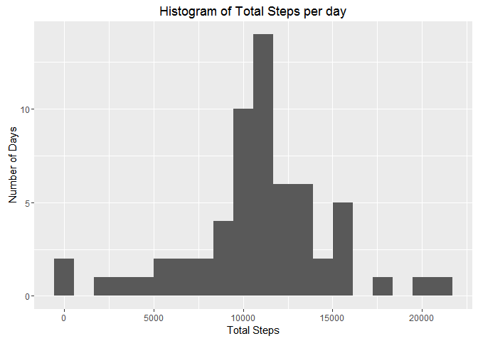

```r
        ## Recalculate the total number of steps per day using Imputed Values for NA's
        impsteps<- wd %>%
                   group_by(date) %>%
                   summarize (total = sum(steps))

        ## Create plot
        g<-ggplot(impsteps,aes(impsteps$total)) +
                geom_histogram(bins = 20)+
                ggtitle("Histogram of Total Steps per day") +
                xlab("Total Steps") +
                ylab("Number of Days")
        print(g)
```

### Mean & Median of total number of steps taken each day

```r
stepmean2<-mean(impsteps$total)
stepmedian2<-median(impsteps$total)
stepmean2p<-prettyNum(stepmean2,big.mark = ",")
stepmedian2p<-prettyNum(stepmedian2,big.mark = ",")
```

The mean number of steps taken per day accounting for missing values is: 10,766.19.  
The median number of steps taken per day accounting for missing values is: 10,766.19.

```r
        diffmean <- stepmean2 - meansteps
        diffmedian <- stepmedian2 - stepmedian1
```

## Are there differences in activity patterns between weekdays and weekends?

```r
wd$day<-weekdays(as.POSIXct(wd$date))
wdays <- c("Monday","Tuesday","Wednesday","Thursday","Friday")
wd$wkdy <- factor((wd$day %in% wdays),levels=c(FALSE,TRUE),labels = c("Weekend","Weekday"))

wkdytotsteps<-wd %>%
                group_by(wkdy) %>%
                summarize(totsteps = sum(steps))
stepsperweekday<-wkdytotsteps[2,2]/5
stepsperweekendday<-wkdytotsteps[1,2]/2
weekenddiff<-stepsperweekendday-stepsperweekday
stepsperweekdayp<-prettyNum(stepsperweekday,big.mark = ",")
stepsperweekenddayp <- prettyNum(stepsperweekendday,big.mark = ",")
weekenddiffp<-prettyNum(weekenddiff,big.mark = ",")
```

## Panel Plot - Weekdays vs. Weekends

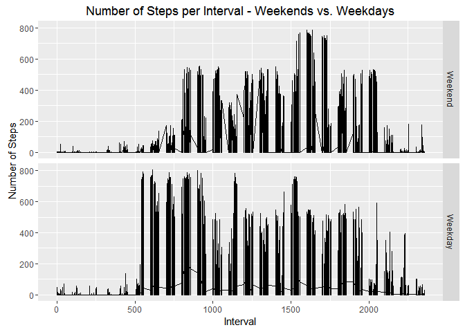

```r
g<-ggplot(wd,aes(interval,steps)) +
        geom_line() +
        facet_grid(wkdy~.) +
        ggtitle("Number of Steps per Interval - Weekends vs. Weekdays") +
        xlab("Interval")+
        ylab("Number of Steps")
print(g)
```